# Outpatient Appointment Scheduler

The purpose of this project is:

1. Implement a Python implementation for the scheduling algorithm developed by Kaandorp / Koole [1] and Koeleman / Koole [2]
2. Improve the efficiency of the computations using alternative algorithms

## Python implementation

The original code was written in PHP and served as a [web application](https://www.gerkoole.com/OBP/appointment-scheduler.php). In a first iteration we have replicated the code in Python and tested its functionality.

While testing the initial Python implementation we observed very high calculation times which would make it unsuitable for real use cases. As a first improvement we reviewed all the `for` loops and eliminated redundancy.

We noticed for instance, that in the original design for each round in the loop a Poisson distribution had to be recreated. However the base parameters of the distribution were the same. Therefore we placed the routine outside of the loop.

The algorithm also contains a routine that generates a solution by gradually shifting one patient through the schedule to see whether it optimizes on an objective score. In the original design each time after a patent was shifted one position a Markov Chain (?) was recalculated starting at the first time slot in the schedule. We realized that up till the time slot where the actual patient’s shift took place the schedule and the corresponding Markov Chain was the same. We could save time by starting the recalculation from the shifted time slot.

## Alternative algorithms

### Genetic Algorithm

We implemented a genetic algorithm that builds generations of populations of possible schedules. Individual schedules are encoded as lists with length equal to the number of time slots. Each list item contains the number of patients at a particular time slot. For instance a schedule with 8 time slots and 6 patients could be encoded as `[2, 0, 1, 0, 2, 0, 0, 1]` or `[2, 0, 2, 0, 1, 0, 0, 1]`.

Each schedule is an individual in a population. A new population is created from a previous schedule. Each newly created population is called a generation. The individuals in the new generation are created by applying natural selection, crossover and mutation.

#### Natural selection

For each individual a fitness score is calculated. This is the same as the objective value from the other approaches. Using the total set of fitness scores a distribution is fitted where the fitness scores are mapped to probability scores. The highest fitness scores have the highest probabilities.

#### Crossover

From the old population two parent schedules are sampled. Schedules with a higher fitness score are more likely to be selected. Using a crossover routine two child schedules are generated. During a crossover patients are transferred from parent 1 to parent 2, one at a time. To maintain the fixed total balance of patients in a schedule in a second round the same number of of patients are transferred from parent 2 to parent 1. The position or time slot from which patients are transferred and are transferred to depends on the number of patients in the time slots. For the parent that loses patients time slots with high patient numbers are more likely to be chosen. For the receiving parent time slots with smaller amounts of patients are more likely to be picked as a destination for new patients.

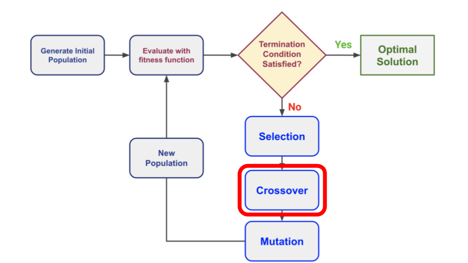

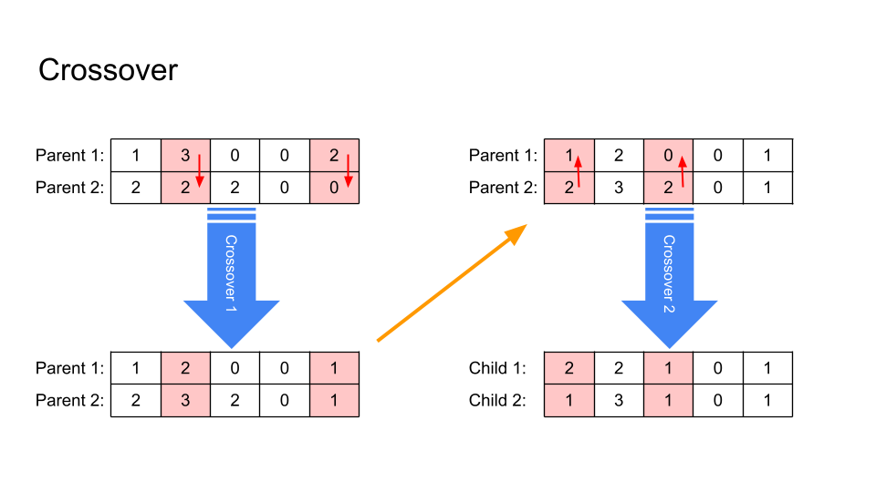

## References

- [1] Kaandorp, G. C., & Koole, G. (2007). Optimal outpatient appointment scheduling. Health care management science, 10(3), 217-229.
- [2] Koeleman, P. M., & Koole, G. M. (2012). Optimal outpatient appointment scheduling with emergency arrivals and general service times. IIE Transactions on Healthcare Systems Engineering, 2(1), 14-30.